# Coursera: Practical Machine Learning Project

zwsun

December 22, 2014

## Background

Using devices such as Jawbone Up, Nike FuelBand, and Fitbit it is now possible to collect a large amount of data about personal activity relatively inexpensively. These type of devices are part of the quantified self movement – a group of enthusiasts who take measurements about themselves regularly to improve their health, to find patterns in their behavior, or because they are tech geeks. One thing that people regularly do is quantify how much of a particular activity they do, but they rarely quantify how well they do it. In this project, your goal will be to use data from accelerometers on the belt, forearm, arm, and dumbell of 6 participants. They were asked to perform barbell lifts correctly and incorrectly in 5 different ways. More information is available from the website here: [http://groupware.les.inf.puc-rio.br/har](http://groupware.les.inf.puc-rio.br/har#weight_lifting_exercises)

## Load data

First, we load the training and testing data. Since there are too many characters like “NA”, “”, “#DIV/0!” in the data, we just set them to be NA.

```r
library(caret)
training <- read.csv(file = "data/pml-training.csv", na.strings=c("NA", "", "#DIV/0!"))
testing <- read.csv(file = "data/pml-testing.csv", na.strings=c("NA", "", "#DIV/0!"))
str(training, list.len = 10, vec.len =  10)
```

```
## 'data.frame':    19622 obs. of  160 variables:
##  $ X                       : int  1 2 3 4 5 6 7 8 9 10 11 12 13 14 15 16 17 18 19 20 21 22 23 24 25 ...
##  $ user_name               : Factor w/ 6 levels "adelmo","carlitos",..: 2 2 2 2 2 2 2 2 2 2 2 2 2 2 2 2 2 2 2 2 2 2 2 2 2 ...
##  $ raw_timestamp_part_1    : int  1323084231 1323084231 1323084231 1323084232 1323084232 1323084232 1323084232 1323084232 1323084232 1323084232 1323084232 1323084232 1323084232 1323084232 1323084232 1323084232 1323084232 1323084232 1323084232 1323084232 1323084232 1323084232 1323084232 1323084232…
##  $ raw_timestamp_part_2    : int  788290 808298 820366 120339 196328 304277 368296 440390 484323 484434 500302 528316 560359 576390 604281 644302 692324 732306 740353 788335 876301 892313 932285 996313 28311 ...
##  $ cvtd_timestamp          : Factor w/ 20 levels "02/12/2011 13:32",..: 9 9 9 9 9 9 9 9 9 9 9 9 9 9 9 9 9 9 9 9 9 9 9 9 9 ...
##  $ new_window              : Factor w/ 2 levels "no","yes": 1 1 1 1 1 1 1 1 1 1 1 1 1 1 1 1 1 1 1 1 1 1 1 2 1 ...
##  $ num_window              : int  11 11 11 12 12 12 12 12 12 12 12 12 12 12 12 12 12 12 12 12 12 12 12 12 13 ...
##  $ roll_belt               : num  1.41 1.41 1.42 1.48 1.48 1.45 1.42 1.42 1.43 1.45 1.45 1.43 1.42 1.42 1.45 1.48 1.51 1.55 1.57 1.59 1.6 1.57 1.56 1.51 1.53 ...
##  $ pitch_belt              : num  8.07 8.07 8.07 8.05 8.07 8.06 8.09 8.13 8.16 8.17 8.18 8.18 8.2 8.21 8.2 8.15 8.12 8.08 8.06 8.07 8.1 8.09 8.1 8.1 8.11 ...
##  $ yaw_belt                : num  -94.4 -94.4 -94.4 -94.4 -94.4 -94.4 -94.4 -94.4 -94.4 -94.4 -94.4 -94.4 -94.4 -94.4 -94.4 -94.4 -94.4 -94.4 -94.4 -94.4 -94.4 -94.4 -94.3 -94.4 -94.4 ...
##   [list output truncated]
```

## Feature Extration

From the page, we know that the timestamp and window data is just a time record, that has no affection for our response variable *classe*, so we remove them as below.

```r
trainingN <- subset(training, select =
                      -c(X, user_name,
                         raw_timestamp_part_1, raw_timestamp_part_2, cvtd_timestamp,
                         new_window, num_window)
)
```

After that, when we explore the data, we find that many variables filled with NAs. That is meaningless, possibly that data was never measured. So we remove that data again.

```r
var.bad <- function(x){sum(is.na(x)*1)>length(x)/2}
matrix.littleNA <- function(m){
  threshold = dim(m)[1]/2
  r = c()
  for( v in 1:dim(m)[2]){
    if(sum(is.na(m[, v])*1) < threshold) r[length(r)+1] = v
  }
  r
}
trainingN <- subset(trainingN, select = matrix.littleNA(trainingN))
str(trainingN, list.len = 10, vec.len =  10)
```

```
## 'data.frame':    19622 obs. of  53 variables:
##  $ roll_belt           : num  1.41 1.41 1.42 1.48 1.48 1.45 1.42 1.42 1.43 1.45 1.45 1.43 1.42 1.42 1.45 1.48 1.51 1.55 1.57 1.59 1.6 1.57 1.56 1.51 1.53 ...
##  $ pitch_belt          : num  8.07 8.07 8.07 8.05 8.07 8.06 8.09 8.13 8.16 8.17 8.18 8.18 8.2 8.21 8.2 8.15 8.12 8.08 8.06 8.07 8.1 8.09 8.1 8.1 8.11 ...
##  $ yaw_belt            : num  -94.4 -94.4 -94.4 -94.4 -94.4 -94.4 -94.4 -94.4 -94.4 -94.4 -94.4 -94.4 -94.4 -94.4 -94.4 -94.4 -94.4 -94.4 -94.4 -94.4 -94.4 -94.4 -94.3 -94.4 -94.4 ...
##  $ total_accel_belt    : int  3 3 3 3 3 3 3 3 3 3 3 3 3 3 3 3 3 3 3 3 3 3 3 3 3 ...
##  $ gyros_belt_x        : num  0 0.02 0 0.02 0.02 0.02 0.02 0.02 0.02 0.03 0.03 0.02 0.02 0.02 0 0 0 0 0 0.02 0.02 0.02 0.02 0.02 0.03 ...
##  $ gyros_belt_y        : num  0 0 0 0 0.02 0 0 0 0 0 0 0 0 0 0 0 0 0.02 0 0 0 0.02 0 0 0 ...
##  $ gyros_belt_z        : num  -0.02 -0.02 -0.02 -0.03 -0.02 -0.02 -0.02 -0.02 -0.02 0 -0.02 -0.02 0 -0.02 0 0 -0.02 0 -0.02 -0.02 -0.02 -0.02 -0.02 -0.02 0 ...
##  $ accel_belt_x        : int  -21 -22 -20 -22 -21 -21 -22 -22 -20 -21 -21 -22 -22 -22 -21 -21 -21 -21 -20 -22 -20 -21 -21 -20 -19 ...
##  $ accel_belt_y        : int  4 4 5 3 2 4 3 4 2 4 2 2 4 4 2 4 4 5 5 5 1 3 4 4 4 ...
##  $ accel_belt_z        : int  22 22 23 21 24 21 21 21 24 22 23 23 21 21 22 23 22 21 21 22 20 21 21 22 21 ...
##   [list output truncated]
```

Now the data is clean, let’s begin to build the model.

## Model Buiding

To build our model, I divide the data into two parts, one for training and the other for validation. Here I used the random forest to build my model. And I also used the cross validation to select the variables and optimize my model. To get a quick result, I set the cross validation fold number to be 2.

```r
set.seed(16888)
inTrain <- createDataPartition(y=trainingN$classe, p=0.1, list=FALSE)
training.rf <- trainingN[inTrain, ]
testing.rf <- trainingN[-inTrain, ]
modFit <- train(classe ~ ., method="rf", trControl=trainControl(method="cv", number = 2),
                data=training.rf)
varImp(modFit)
```

```
## rf variable importance
##
##   only 20 most important variables shown (out of 52)
##
##                      Overall
## roll_belt             100.00
## pitch_forearm          68.94
## yaw_belt               50.36
## magnet_dumbbell_z      48.12
## magnet_dumbbell_y      41.13
## pitch_belt             37.16
## roll_dumbbell          27.82
## roll_forearm           27.09
## magnet_dumbbell_x      24.43
## accel_dumbbell_y       22.36
## magnet_belt_y          20.99
## magnet_belt_z          18.49
## accel_forearm_x        18.47
## accel_belt_z           14.27
## magnet_forearm_z       13.10
## accel_dumbbell_z       12.02
## yaw_dumbbell           11.10
## yaw_arm                10.60
## magnet_belt_x          10.45
## total_accel_dumbbell   10.34
```

```r
print(modFit$finalModel)
```

```
##
## Call:
##  randomForest(x = x, y = y, mtry = param$mtry)
##                Type of random forest: classification
##                      Number of trees: 500
## No. of variables tried at each split: 27
##
##         OOB estimate of  error rate: 5.8%
## Confusion matrix:
##     A   B   C   D   E class.error
## A 546   5   3   3   1  0.02150538
## B  23 339  12   5   1  0.10789474
## C   1  13 323   6   0  0.05830904
## D   2   1  20 297   2  0.07763975
## E   0   4   5   7 345  0.04432133
```

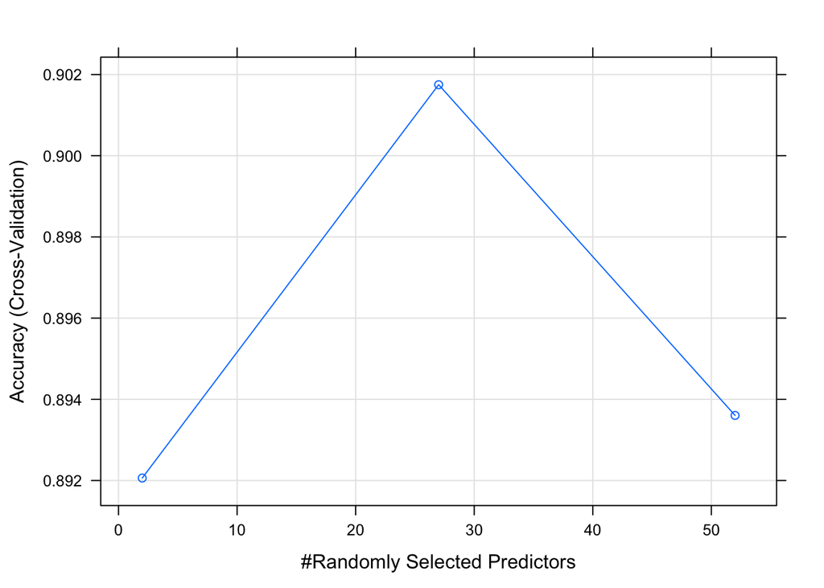

```r
plot(modFit)
```

## Model Accuracy

To estimate the accuracy of our model, we use a independent validation part of the whole data

```r
testing.predict <- predict(modFit, testing.rf)
cm <- confusionMatrix(testing.rf$classe, testing.predict)
cm
```

```
## Confusion Matrix and Statistics
##
##           Reference
## Prediction    A    B    C    D    E
##          A 4931   32   23   29    7
##          B  153 3164   90   10    0
##          C    1  180 2867   19   12
##          D   10   17  116 2744    7
##          E    5   51   57   38 3095
##
## Overall Statistics
##
##                Accuracy : 0.9515
##                  95% CI : (0.9482, 0.9546)
##     No Information Rate : 0.2888
##     P-Value [Acc > NIR] : < 2.2e-16
##
##                   Kappa : 0.9386
##  Mcnemar's Test P-Value : < 2.2e-16
##
## Statistics by Class:
##
##                      Class: A Class: B Class: C Class: D Class: E
## Sensitivity            0.9669   0.9187   0.9093   0.9662   0.9917
## Specificity            0.9928   0.9822   0.9854   0.9899   0.9896
## Pos Pred Value         0.9819   0.9260   0.9311   0.9482   0.9535
## Neg Pred Value         0.9866   0.9803   0.9804   0.9935   0.9982
## Prevalence             0.2888   0.1950   0.1786   0.1608   0.1767
## Detection Rate         0.2793   0.1792   0.1624   0.1554   0.1753
## Detection Prevalence   0.2844   0.1935   0.1744   0.1639   0.1838
## Balanced Accuracy      0.9798   0.9504   0.9473   0.9780   0.9906
```

From the output, we can estimate the accuracy to be 0.9514668. And the 95% confidence interval is between 0.9481938 and 0.95459, so I can estimate the out of sample error rate is less than 0.0518062 at the 95% confidence interval.

## Test Data Prediction

At last, let’s try to predict the testing data.

```r
testing[, "classe"] = predict(modFit, testing)
testing[, c("problem_id", "classe")]
```

```
##    problem_id classe
## 1           1      B
## 2           2      A
## 3           3      B
## 4           4      A
## 5           5      A
## 6           6      E
## 7           7      D
## 8           8      B
## 9           9      A
## 10         10      A
## 11         11      B
## 12         12      C
## 13         13      B
## 14         14      A
## 15         15      E
## 16         16      E
## 17         17      A
## 18         18      B
## 19         19      B
## 20         20      B
```

## Further More

The accuracy is very good though I only used 10 percent of the data to train the model for a immediate result. This can be improved when running more data with more time.

## Declaration

The data for this project come from this source: http://groupware.les.inf.puc-rio.br/har.